# Wrapper Seurat -> RISC -> Seurat

Martin Loza

On this workflow I will create and use a wrapper function to ease the usage of RISC with Seurat objects.

```r
library(Seurat)
library(RISC)
library(ggplot2)
library(splatter)
library(patchwork)

seed = 12

set.seed(seed)
mytheme <- theme_classic() + theme(text = element_text(size = 20))
theme_set(mytheme)
testName <- "Simulation"

options(future.globals.maxSize = 4e10)

knitr::opts_chunk$set(
    fig.align = "center",
    fig.height = 5,
    fig.width = 10
)
```

# Simulate data with Splatter

We use a simple simulated dataset with three celltypes and two batches.

```r
nCells = 1200
nGenes = 2000

params <- newSplatParams(batchCells = c(nCells,nCells),
                         nGenes = nGenes)

sim <- splatSimulate(params,
                     method = "groups",
                     group.prob = c(0.4,0.3,0.3),
                     de.prob = c(0.2,0.25,0.35),
                     seed = seed,
                     verbose = FALSE)

md <- data.frame(colData(sim))
x <- CreateSeuratObject(counts = assay(sim , "counts"), assay = "RNA",
                        min.cells = 5, project = testName, meta.data = md)

xl <- SplitObject(x, split.by = "Batch")

x
```

```
An object of class Seurat
1988 features across 2400 samples within 1 assay
Active assay: RNA (1988 features, 0 variable features)
```

```r
xl
```

```
$Batch1
An object of class Seurat
1988 features across 1200 samples within 1 assay
Active assay: RNA (1988 features, 0 variable features)

$Batch2
An object of class Seurat
1988 features across 1200 samples within 1 assay
Active assay: RNA (1988 features, 0 variable features)
```

# Create wrapper function

For now, the wrapper function involves again to normalize and define variable features using the specific RISC functions as this ease the interaction and correction using RISC objects.# TODO: Explore the RISC object and find a way to directly assign normalized data and variable features.

```r
RunRISC <- function(Uncorrected = NULL, batch = NULL){

  if(!is.list(Uncorrected)){
    yl <- SplitObject(Uncorrected, split.by = batch)
  }else{
    yl <- Uncorrected
  }

  yl <- lapply(X = yl, FUN = GetAssayData, assay = "RNA", slot = "counts")

  # Pre-processing steps using RISC
  yl <- lapply(yl, FUN = function(i){
    tmp <- as.matrix(i)
    genes <- data.frame(rownames(tmp))
    rownames(genes) <- rownames(tmp)
    cell <- data.frame(colnames(tmp))
    rownames(cell) <- colnames(tmp)
    return(RISC::readscdata(count = tmp, cell = cell, gene = genes))
  })

  yl <- lapply(yl, scFilter)
  yl <- lapply(yl, scNormalize)
  yl <- lapply(yl, scDisperse)

  y <- RISC::scMultiIntegrate(objects = yl)
  rm(yl)

  # Re-arrange data to use Seurat objects
  colData <- y@coldata
  rowData <- y@rowdata
  tmp <- as.matrix(y@assay$logcount)
  colnames(tmp) <- colData$scBarcode
  rownames(tmp) <- rowData$Symbol
  rm(y)

  if(is.list(Uncorrected)){
    x <- Reduce(merge, Uncorrected)
  }else{
    x <- Uncorrected
  }

  x <- x[rowData$Symbol, colData$scBarcode]
  x[["integrated"]] <- Seurat::CreateAssayObject(counts = tmp)
  DefaultAssay(x) <- "integrated"

  return(x)
}
```

# Correct-batch effects

We first test the wrapper function using a single Seurat object

```r
x <- RunRISC(Uncorrected = x, batch = "Batch")
x
```

```
An object of class Seurat
3954 features across 2280 samples within 2 assays
Active assay: integrated (1977 features, 0 variable features)
 1 other assay present: RNA
```

Now we test using a list of Seurat objects.

```r
x2 <- RunRISC(Uncorrected = xl, batch = "Batch")
x2
```

```
An object of class Seurat
3954 features across 2280 samples within 2 assays
Active assay: integrated (1977 features, 0 variable features)
 1 other assay present: RNA
```

# Visualization

Once we get our Seurat objects with the corrected assay, we perform PCA and choose the number of dimensions by looking at the elbow plots of the standard deviation of the principal components. On this case we think that 10 dimension would be enough to capture the majority of information from our integrated dataset.

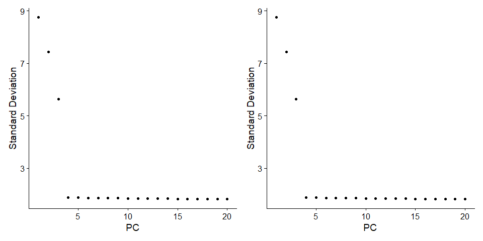

```r
VariableFeatures(x) <- rownames(x)
VariableFeatures(x2) <- rownames(x2)
x <-  ScaleData(x, verbose = FALSE)
x2 <-  ScaleData(x2, verbose = FALSE)
x <- RunPCA(x, npcs = 20, verbose = FALSE)
x2 <- RunPCA(x2, npcs = 20, verbose = FALSE)
ElbowPlot(x) + ElbowPlot(x2)
```

We then run umap using the first 10 dimensions from PCA

```r
x <- RunUMAP(x, reduction = "pca", dims = 1:10)
```

```
The default method for RunUMAP has changed from calling Python UMAP via reticulate to the R-native UWOT using the cosine metric
To use Python UMAP via reticulate, set umap.method to 'umap-learn' and metric to 'correlation'
This message will be shown once per session12:22:36 UMAP embedding parameters a = 0.9922 b = 1.112
12:22:39 Found 3 connected components, falling back to 'spca' initialization with init_sdev = 1
12:22:39 PCA: 2 components explained 70.08% variance
```

```r
x2 <- RunUMAP(x2, reduction = "pca", dims = 1:10)
```

```
12:22:51 Found 3 connected components, falling back to 'spca' initialization with init_sdev = 1
12:22:51 PCA: 2 components explained 70.08% variance
```

# Plots

Finally we can plot our data and color the cells by group and batch to visually verify the mixing among batches.

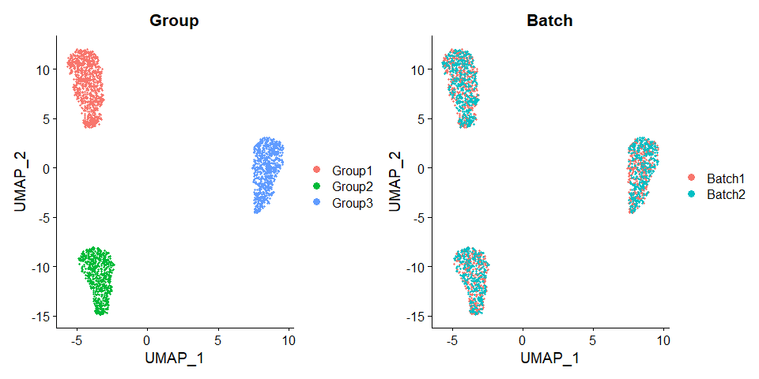

```r
Seurat::DimPlot(x, group.by = "Group") + Seurat::DimPlot(x, group.by = "Batch")
```

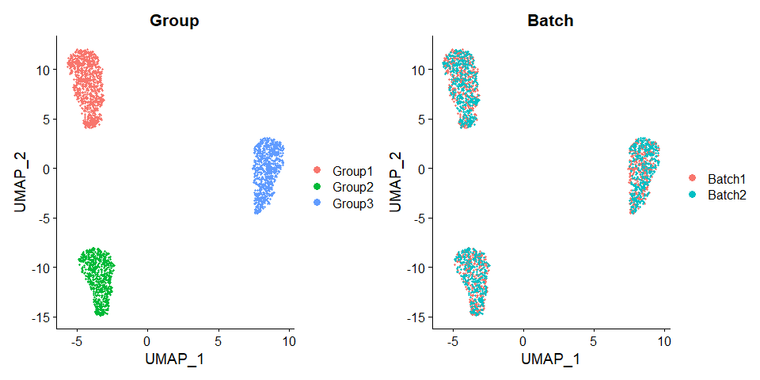

```r
Seurat::DimPlot(x2, group.by = "Group") + Seurat::DimPlot(x2, group.by = "Batch")
```

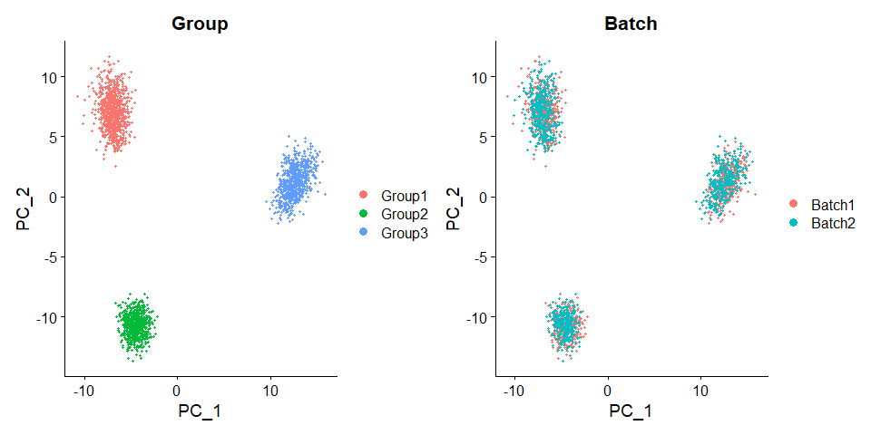

```r
Seurat::DimPlot(x, group.by = "Group", reduction = "pca") +
  Seurat::DimPlot(x, group.by = "Batch", reduction = "pca")
```

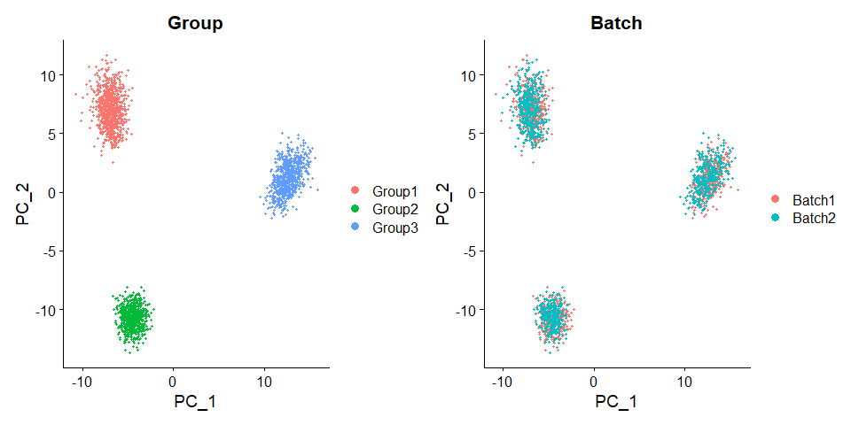

```r
Seurat::DimPlot(x2, group.by = "Group", reduction = "pca") +
  Seurat::DimPlot(x2, group.by = "Batch", reduction = "pca")
```

CONCLUSIONS: The wrapper function works with a single or a list of Seurat objects. Again, the integrations look nice on this scenario, but it is still necessary to asses RISC in more complicated scenarios. The groups from the UMAP plot look a bit deformed (e.g. non-circular) as compared with previous experiences with other batch-effects correction tools.